# PSTAT131 HW6

Liangchen Xia

2022-05-25

## Tree-Based Models

For this assignment, we will continue working with the file `"pokemon.csv"`, found in `/data`. The file is from Kaggle: https://www.kaggle.com/abcsds/pokemon.

The [Pokémon](https://www.pokemon.com/us/) franchise encompasses video games, TV shows, movies, books, and a card game. This data set was drawn from the video game series and contains statistics about 721 Pokémon, or “pocket monsters.” In Pokémon games, the user plays as a trainer who collects, trades, and battles Pokémon to (a) collect all the Pokémon and (b) become the champion Pokémon trainer.

Each Pokémon has a [primary type](https://bulbapedia.bulbagarden.net/wiki/Type) (some even have secondary types). Based on their type, a Pokémon is strong against some types, and vulnerable to others. (Think rock, paper, scissors.) A Fire-type Pokémon, for example, is vulnerable to Water-type Pokémon, but strong against Grass-type.

The goal of this assignment is to build a statistical learning model that can predict the **primary type** of a Pokémon based on its generation, legendary status, and six battle statistics.

**Note: Fitting ensemble tree-based models can take a little while to run. Consider running your models outside of the .Rmd, storing the results, and loading them in your .Rmd to minimize time to knit.**

Read the required libraries first

```r
set.seed(10086)
# load libraries
library(corrplot)
library(tidyverse)
library(tidymodels)
library(dplyr)
library(discrim)
library(glmnet)
library(janitor)
library(rpart.plot)
library(randomForest)
library(ranger)
library(vip)
library(xgboost)
```

### Exercise 1

Read in the data and set things up as in Homework 5:

```r
pokemon <- read_csv("data/pokemon.csv")
pokemon
```

```
## # A tibble: 800 x 13
##      `#` Name   `Type 1` `Type 2` Total    HP Attack Defense `Sp. Atk` `Sp. Def`
##    <dbl> <chr>  <chr>    <chr>    <dbl> <dbl>  <dbl>   <dbl>     <dbl>     <dbl>
##  1     1 Bulba~ Grass    Poison     318    45     49      49        65        65
##  2     2 Ivysa~ Grass    Poison     405    60     62      63        80        80
##  3     3 Venus~ Grass    Poison     525    80     82      83       100       100
##  4     3 Venus~ Grass    Poison     625    80    100     123       122       120
##  5     4 Charm~ Fire     <NA>       309    39     52      43        60        50
##  6     5 Charm~ Fire     <NA>       405    58     64      58        80        65
##  7     6 Chari~ Fire     Flying     534    78     84      78       109        85
##  8     6 Chari~ Fire     Dragon     634    78    130     111       130        85
##  9     6 Chari~ Fire     Flying     634    78    104      78       159       115
## 10     7 Squir~ Water    <NA>       314    44     48      65        50        64
## # ... with 790 more rows, and 3 more variables: Speed <dbl>, Generation <dbl>,
## #   Legendary <lgl>
```

- Use `clean_names()`
- Filter out the rarer Pokémon types
- Convert `type_1` and `legendary` to factors

```r
#now we Clean Names
pokemon <- pokemon %>% clean_names()


pokemon <- pokemon %>% filter(type_1 == "Bug" | type_1 == "Fire" |
                          type_1 == "Grass" | type_1 == "Normal" |
                          type_1 == "Water" | type_1 == "Psychic")
# Convert type_1, legendary, generation to factors
pokemon$type_1 <- as.factor(pokemon$type_1)
pokemon$generation <- as.factor(pokemon$generation)
pokemon$legendary <- as.factor(pokemon$legendary)
pokemon
```

```
## # A tibble: 458 x 13
##    number name      type_1 type_2 total    hp attack defense sp_atk sp_def speed
##     <dbl> <chr>     <fct>  <chr>  <dbl> <dbl>  <dbl>   <dbl>  <dbl>  <dbl> <dbl>
##  1      1 Bulbasaur Grass  Poison   318    45     49      49     65     65    45
##  2      2 Ivysaur   Grass  Poison   405    60     62      63     80     80    60
##  3      3 Venusaur  Grass  Poison   525    80     82      83    100    100    80
##  4      3 Venusaur~ Grass  Poison   625    80    100     123    122    120    80
##  5      4 Charmand~ Fire   <NA>     309    39     52      43     60     50    65
##  6      5 Charmele~ Fire   <NA>     405    58     64      58     80     65    80
##  7      6 Charizard Fire   Flying   534    78     84      78    109     85   100
##  8      6 Charizar~ Fire   Dragon   634    78    130     111    130     85   100
##  9      6 Charizar~ Fire   Flying   634    78    104      78    159    115   100
## 10      7 Squirtle  Water  <NA>     314    44     48      65     50     64    43
## # ... with 448 more rows, and 2 more variables: generation <fct>,
## #   legendary <fct>
```

Do an initial split of the data; you can choose the percentage for splitting. Stratify on the outcome variable.

```r
#Initial Split
pokemon_split <- initial_split(data = pokemon,
                            prop = 0.7,
                            strate = type_1)
train <- training(pokemon_split)
test <- testing(pokemon_split)
dim(train)
```

```
## [1] 320  13
```

```r
dim(test)
```

```
## [1] 138  13
```

Fold the training set using *v*-fold cross-validation, with `v = 5`. Stratify on the outcome variable.

```r
folds <- vfold_cv(data = train, v = 5, strata = type_1)
```

Set up a recipe to predict `type_1` with `legendary`, `generation`, `sp_atk`, `attack`, `speed`, `defense`, `hp`, and `sp_def`:

- Dummy-code `legendary` and `generation`;
- Center and scale all predictors.

```r
pokemon_recipe <- recipe(formula = type_1 ~ legendary + generation + sp_atk + attack + speed + defense + hp + sp_def,
                         data = train) %>%
  step_dummy(legendary) %>%
  step_dummy(generation) %>%
  step_normalize(all_predictors())
```

### Exercise 2

Create a correlation matrix of the training set, using the `corrplot` package. *Note: You can choose how to handle the continuous variables for this plot; justify your decision(s).*

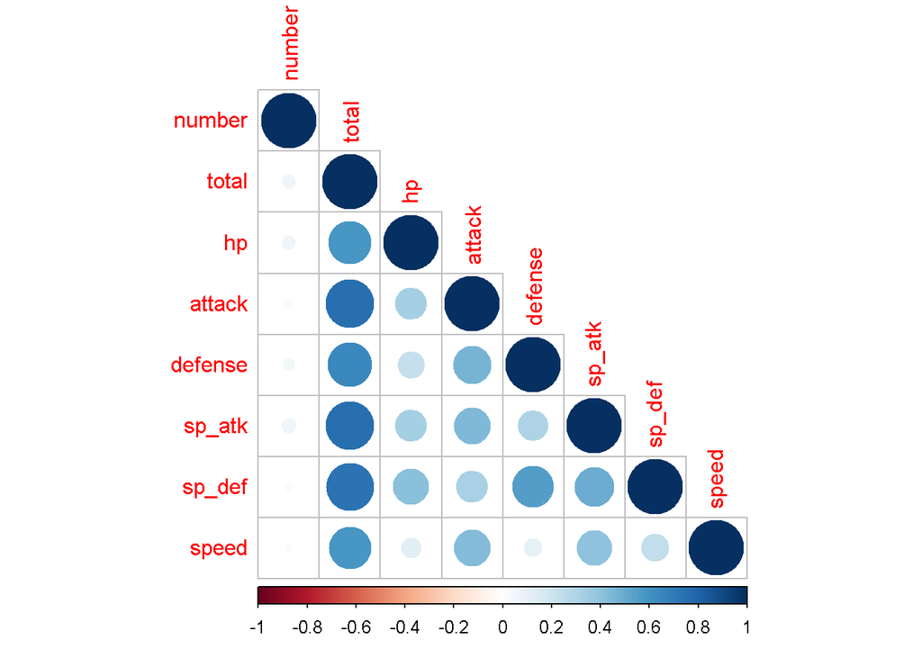

```r
pokemon %>% select(is.numeric) %>% cor() %>% corrplot(type = "lower")
```

What relationships, if any, do you notice? Do these relationships make sense to you?

First, as the graph we could know the number is useless to help us check. It’s just the pokemon number. When we see the total, all of the varibale is positively correlated. Like hp, attack, defense, sp_atk, sp_def and speed. And there is not too strong realstionship between those variables. Sp_def and defense have higher positively correlated than other.

### Exercise 3

First, set up a decision tree model and workflow. Tune the `cost_complexity` hyperparameter. Use the same levels we used in Lab 7 – that is, `range = c(-3, -1)`. Specify that the metric we want to optimize is `roc_auc`.

```r
pokemon_tree_spec <- decision_tree(cost_complexity = tune()) %>% set_mode("classification") %>% set_engine("rpart")

pokemon_tree_workflow <- workflow() %>% add_recipe(pokemon_recipe) %>% add_model(pokemon_tree_spec)

param_grid_tree <- grid_regular(cost_complexity(range = c(-3, -1)), levels = 10)

tune_res_tree <- tune_grid(pokemon_tree_workflow, resamples = folds, grid = param_grid_tree, metrics = metric_set(roc_auc))
```

Print an `autoplot()` of the results. What do you observe? Does a single decision tree perform better with a smaller or larger complexity penalty?

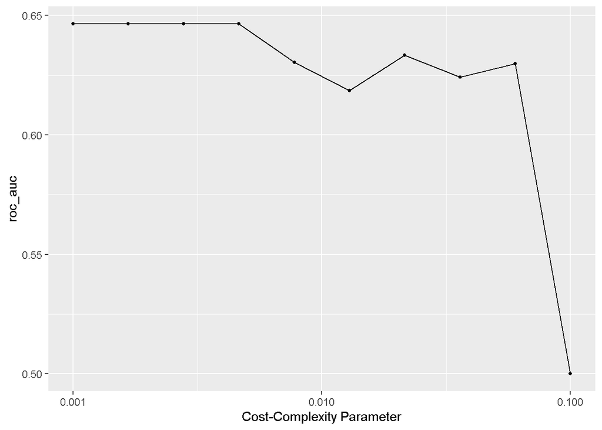

```r
autoplot(tune_res_tree)
```

As cost-complexity goes up the overall roc auc of our model goes down. There seems to be change in cost complexities on 0.007, 0.02 and 0.055. And then our model goes down really quickly. Until roc_auc to 0.5.

### Exercise 4

What is the `roc_auc` of your best-performing pruned decision tree on the folds? *Hint: Use `collect_metrics()` and `arrange()`.*

```r
collect_metrics(tune_res_tree) %>% arrange(desc(mean))
```

```
## # A tibble: 10 x 7
##    cost_complexity .metric .estimator  mean     n std_err .config
##              <dbl> <chr>   <chr>      <dbl> <int>   <dbl> <chr>
##  1         0.001   roc_auc hand_till  0.646     5 0.0286  Preprocessor1_Model01
##  2         0.00167 roc_auc hand_till  0.646     5 0.0286  Preprocessor1_Model02
##  3         0.00278 roc_auc hand_till  0.646     5 0.0286  Preprocessor1_Model03
##  4         0.00464 roc_auc hand_till  0.646     5 0.0286  Preprocessor1_Model04
##  5         0.0215  roc_auc hand_till  0.633     5 0.0151  Preprocessor1_Model07
##  6         0.00774 roc_auc hand_till  0.630     5 0.0227  Preprocessor1_Model05
##  7         0.0599  roc_auc hand_till  0.630     5 0.0102  Preprocessor1_Model09
##  8         0.0359  roc_auc hand_till  0.624     5 0.00818 Preprocessor1_Model08
##  9         0.0129  roc_auc hand_till  0.619     5 0.0205  Preprocessor1_Model06
## 10         0.1     roc_auc hand_till  0.5       5 0       Preprocessor1_Model10
```

```r
# the top result  is the best cost_complexity in roc_auc
```

The roc_auc of the best-performing pruned decision tree was 0.646, which has a corresponding cost_complexity of 0.001, 0.00167, 0.00278 and 0.00464. Those all had the same performance.

### Exercise 5

Using `rpart.plot`, fit and visualize your best-performing pruned decision tree with the *training* set.

```r
best_parameter_tree <- select_best(tune_res_tree, metric = "roc_auc")
best_parameter_tree
```

```
## # A tibble: 1 x 2
##   cost_complexity .config
##             <dbl> <chr>
## 1           0.001 Preprocessor1_Model01
```

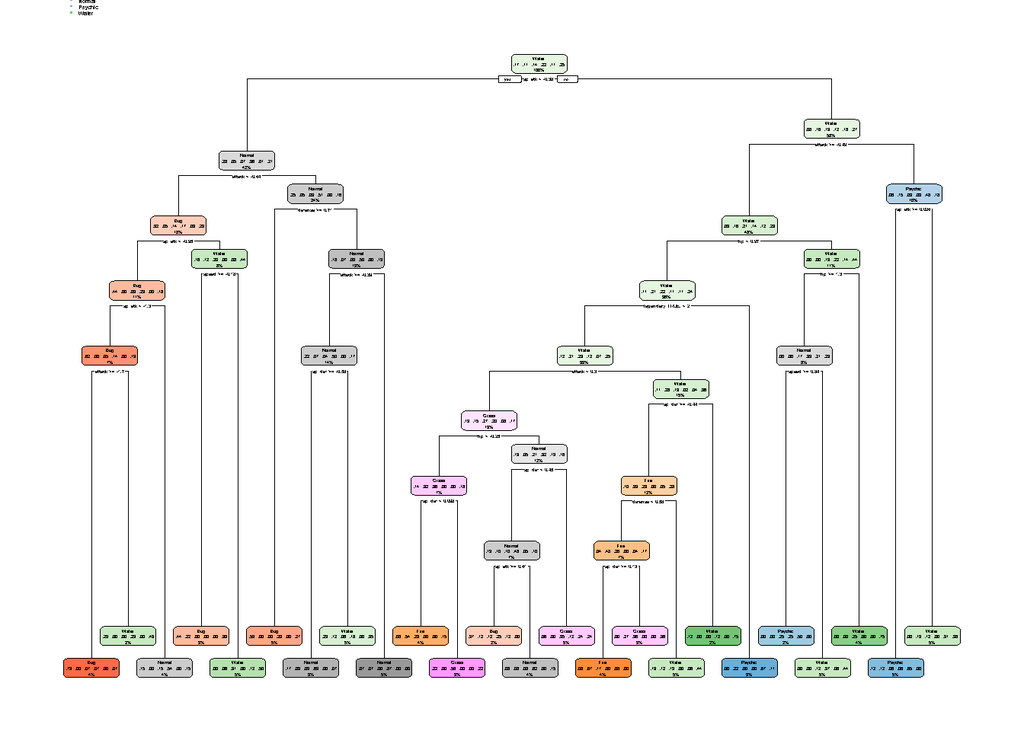

```r
#finalizing workflow and fitting that model to the training data
pokemon_tree_final <- finalize_workflow(pokemon_tree_workflow, best_parameter_tree)
pokemon_tree_final_fit <- fit(pokemon_tree_final, data = train)


# visualizing best performing pruned decision tree
pokemon_tree_final_fit %>% extract_fit_engine() %>% rpart.plot(roundint = FALSE)
```

### Exercise 5

Now set up a random forest model and workflow. Use the `ranger` engine and set `importance = "impurity"`. Tune `mtry`, `trees`, and `min_n`. Using the documentation for `rand_forest()`, explain in your own words what each of these hyperparameters represent.

```r
pokemon_rf_spec <- rand_forest(mtry=tune(), trees=tune(), min_n=tune()) %>%
  set_engine("randomForest", importance = TRUE) %>%
  set_mode("classification")


pokemon_rf_workflow <- workflow() %>%
  add_recipe(pokemon_recipe) %>%
  add_model(pokemon_rf_spec)

regular_grid <- grid_regular(mtry(range = c(1,8)), trees(range = c(10,1000)), min_n(range = c(1, 10)), levels = 8)
regular_grid
```

```
## # A tibble: 512 x 3
##     mtry trees min_n
##    <int> <int> <int>
##  1     1    10     1
##  2     2    10     1
##  3     3    10     1
##  4     4    10     1
##  5     5    10     1
##  6     6    10     1
##  7     7    10     1
##  8     8    10     1
##  9     1   151     1
## 10     2   151     1
## # ... with 502 more rows
```

In this part, mtry shows # of randomly selected variables we give each tree to make decisions with. And trees is the trees. I mean the # of trees we will create. min_n shows the data point in a node required to make split.

Create a regular grid with 8 levels each. You can choose plausible ranges for each hyperparameter. Note that `mtry` should not be smaller than 1 or larger than 8. **Explain why not. What type of model would `mtry = 8` represent?**

Our mtry should around 1 to 8. We have total of 8 predictors. we set mtry = 8, it represent the bagging model.

### Exercise 6

Specify `roc_auc` as a metric. Tune the model and print an `autoplot()` of the results. What do you observe? What values of the hyperparameters seem to yield the best performance?

```r
tune_res_rf <- tune_grid(
  pokemon_rf_workflow,
  resamples = folds,
  grid = regular_grid,
  metrics = metric_set(roc_auc))
```

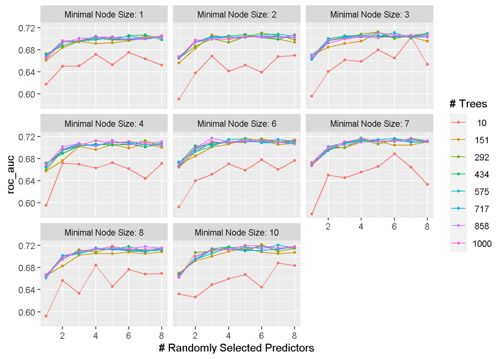

```r
autoplot(tune_res_rf)
```

### Exercise 7

What is the `roc_auc` of your best-performing random forest model on the folds? *Hint: Use `collect_metrics()` and `arrange()`.*

```r
# the top results are best parameters
collect_metrics(tune_res_rf) %>% arrange(desc(mean))
```

```
## # A tibble: 512 x 9
##     mtry trees min_n .metric .estimator  mean     n std_err .config
##    <int> <int> <int> <chr>   <chr>      <dbl> <int>   <dbl> <chr>
##  1     6   292    10 roc_auc hand_till  0.722     5  0.0251 Preprocessor1_Model~
##  2     7   575    10 roc_auc hand_till  0.721     5  0.0261 Preprocessor1_Model~
##  3     5  1000    10 roc_auc hand_till  0.720     5  0.0255 Preprocessor1_Model~
##  4     6  1000    10 roc_auc hand_till  0.720     5  0.0242 Preprocessor1_Model~
##  5     6   434    10 roc_auc hand_till  0.719     5  0.0268 Preprocessor1_Model~
##  6     5  1000     8 roc_auc hand_till  0.719     5  0.0235 Preprocessor1_Model~
##  7     7   858     8 roc_auc hand_till  0.718     5  0.0232 Preprocessor1_Model~
##  8     8   858    10 roc_auc hand_till  0.718     5  0.0242 Preprocessor1_Model~
##  9     6   434     8 roc_auc hand_till  0.718     5  0.0232 Preprocessor1_Model~
## 10     5   575    10 roc_auc hand_till  0.718     5  0.0244 Preprocessor1_Model~
## # ... with 502 more rows
```

```r
best_rf <- select_best(tune_res_rf, metric = "roc_auc")
best_rf
```

```
## # A tibble: 1 x 4
##    mtry trees min_n .config
##   <int> <int> <int> <chr>
## 1     6   292    10 Preprocessor1_Model470
```

### Exercise 8

Create a variable importance plot, using `vip()`, with your best-performing random forest model fit on the *training* set.

Which variables were most useful? Which were least useful? Are these results what you expected, or not?

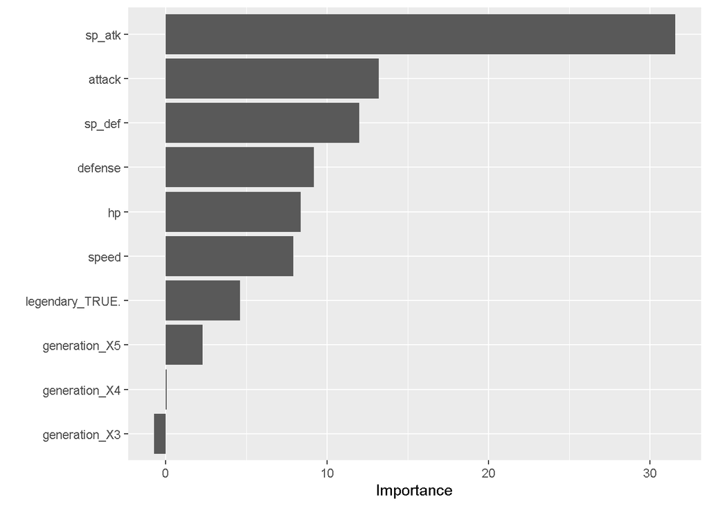

```r
#finalizing workflow and fitting that model to the training data
pokemon_rf_final <- finalize_workflow(pokemon_rf_workflow, best_rf)
pokemon_rf_final_fit <- fit(pokemon_rf_final, data = train)

# visualizing decision tree
vip(pokemon_rf_final_fit %>% extract_fit_engine())
```

As the graph, the most useful is by far sp_atk. It’s double larger than attack and sp_def. The least useful are generation x3 and generation_x4. And generation x3 is negative. I think this is what I expected. I do not play pokemon too much, but sp_def is useful predictor to be identifying pokemon.

### Exercise 9

Finally, set up a boosted tree model and workflow. Use the `xgboost` engine. Tune `trees`. Create a regular grid with 10 levels; let `trees` range from 10 to 2000. Specify `roc_auc` and again print an `autoplot()` of the results.

```r
# Set up boosted tree specification
pokemon_boosted_spec <- boost_tree(trees=tune()) %>%
  set_engine("xgboost") %>%
  set_mode("classification")

#boosted tree workflow
pokemon_boosted_workflow <- workflow() %>%
  add_model(pokemon_boosted_spec) %>%
  add_recipe(pokemon_recipe)

#boosted tree tuning grid
param_grid_boosted <- grid_regular(trees(range = c(10, 2000)),levels = 10)

#resulting values with hyperparameter tuning across CV
tune_res_boosted <- tune_grid(
  pokemon_boosted_workflow,
  resamples = folds,
  grid = param_grid_boosted,
  metrics = metric_set(roc_auc))
```

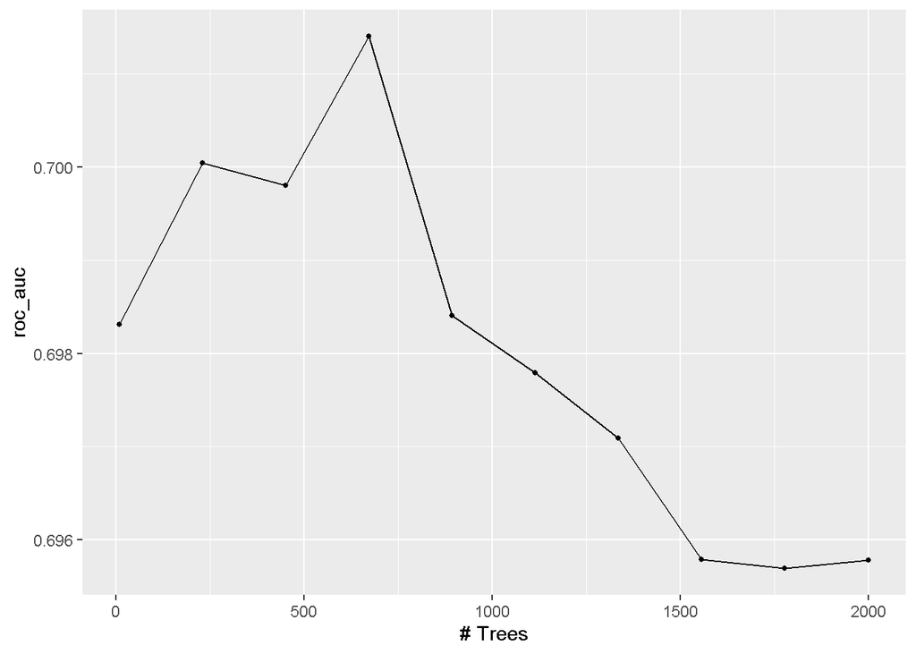

```r
autoplot(tune_res_boosted)
```

What do you observe?

The roc auc increases. And the highest point 673 trees, then the roc auc show a gradually decreasing trend.

What is the `roc_auc` of your best-performing boosted tree model on the folds? *Hint: Use `collect_metrics()` and `arrange()`.*

```r
# the best parameters are the top results
collect_metrics(tune_res_boosted) %>% arrange(desc(mean))
```

```
## # A tibble: 10 x 7
##    trees .metric .estimator  mean     n std_err .config
##    <int> <chr>   <chr>      <dbl> <int>   <dbl> <chr>
##  1   673 roc_auc hand_till  0.701     5  0.0225 Preprocessor1_Model04
##  2   231 roc_auc hand_till  0.700     5  0.0220 Preprocessor1_Model02
##  3   452 roc_auc hand_till  0.700     5  0.0223 Preprocessor1_Model03
##  4   894 roc_auc hand_till  0.698     5  0.0221 Preprocessor1_Model05
##  5    10 roc_auc hand_till  0.698     5  0.0207 Preprocessor1_Model01
##  6  1115 roc_auc hand_till  0.698     5  0.0223 Preprocessor1_Model06
##  7  1336 roc_auc hand_till  0.697     5  0.0222 Preprocessor1_Model07
##  8  1557 roc_auc hand_till  0.696     5  0.0220 Preprocessor1_Model08
##  9  2000 roc_auc hand_till  0.696     5  0.0216 Preprocessor1_Model10
## 10  1778 roc_auc hand_till  0.696     5  0.0216 Preprocessor1_Model09
```

```r
best_paramater_boosted <- select_best(tune_res_boosted, metric = "roc_auc")
best_paramater_boosted
```

```
## # A tibble: 1 x 2
##   trees .config
##   <int> <chr>
## 1   673 Preprocessor1_Model04
```

The best_performing model had a roc_aur of 0.701 at 673 trees.